# operator

```r
library(ggalign)
```

```r
set.seed(123)
small_mat <- matrix(rnorm(56), nrow = 8)
rownames(small_mat) <- paste0("row", seq_len(nrow(small_mat)))
colnames(small_mat) <- paste0("column", seq_len(ncol(small_mat)))
```

# Operators

## Addition operator

> `+`: adds elements to the active plot in the active layout.

The `+` operator is straightforward and should be used as needed.

In `quad_layout()` (`ggheatmap()`/`ggside()`), four nested layouts are available for annotations: `top`, `left`, `bottom`, and `right`. If no active annotation is set, `quad_layout()` (`ggheatmap()`/`ggside()`) treat itself as the active layout. Since there is only one main plot in the `quad_layout()` (`ggheatmap()`/`ggside()`), the main plot is always treated as the active plot in this context.

```
#> → heatmap built with `geom_tile()`
```

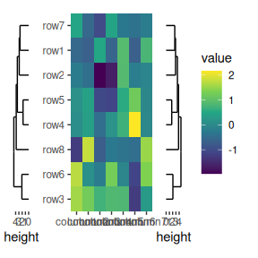

```r
# Initialize the heatmap; by default, no active annotation will be set.
# The active layout is the heatmap layout, and the active plot in the layout is
# the main plot.
ggheatmap(small_mat) +
    # Add elements to the main plot
    scale_fill_viridis_c() +
    # Change the active layout to the left annotation
    anno_left(size = 0.2) +
    # Add a dendrogram in the left annotation
    align_dendro() +
    # Change the active layout to the right annotation
    anno_right(size = 0.2) +
    # Add a dendrogram in the right annotation
    align_dendro()
```

In `ggstack()`/`stack_layout()`, a nested layout will only occur if you pass a `quad_layout()` into `ggstack()`/`stack_layout()`. If the active plot within the `ggstack()`/`stack_layout()` is `quad_layout()`, this `quad_layout()` is treated as the active layout, and the `+` operator will add elements to it, following the same principles as in `quad_layout()`. Otherwise, the `ggstack()`/`stack_layout()` itself is treated as the active layout, and the `+` operator will add elements directly to this plot.

```
#> → heatmap built with `geom_tile()`
```

[figure not shown]

```r
stack_alignh(small_mat) +
    # the dendrogram will be added to the stack
    align_dendro() +
    # Add elements to the dendrogram
    geom_point() +
    # add a heamtap layout to the stack
    ggheatmap() +
    # the active layout is the heamtap layout
    # so following elements will be added to the heatmap layout
    theme(axis.text.x = element_text(angle = -60, hjust = 0)) +
    anno_right() +
    align_dendro()
```

## logical AND operator

> `&`: applies elements to all plots in the layout.

The `&` operator works similarly to `patchwork`, applying an element across all plots in a layout. Since `&` has lower precedence than `+`, it’s generally best to use it at the end of an expression or you should wrap it in parentheses when needed.

```
#> → heatmap built with `geom_tile()`
```

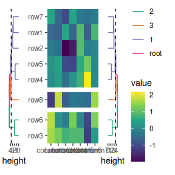

```r
# Initialize the heatmap with color scales and annotations.
ggheatmap(small_mat) +
    scale_fill_viridis_c() +
    anno_left(size = 0.2) +
    # Add a dendrogram in the left annotation and split the dendrogram into 3 groups
    align_dendro(aes(color = branch), k = 3L) +
    anno_right(size = 0.2) +
    # Add a dendrogram in the right annotation and split the dendrogram into 3 groups
    align_dendro(aes(color = branch), k = 3L) &
    # Set color scale for all plots
    scale_color_brewer(palette = "Dark2")
```

## Subtraction operator

The `-` operator is more powerful than the `+` operator, enabling flexible addition of elements to multiple plots. While its use might initially seem unintuitive, the reason behind this is that `-` shares the same precedence group as `+`, which allows it to seamlessly combine with `+`.

### quad_layout()

If the active layout is the `ggheatmap()`/`quad_layout()` itself, the `-` operator behaves similarly to `&`. It applies the specified elements to all plots within the layout.

```
#> → heatmap built with `geom_tile()`
```

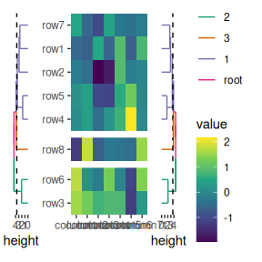

```r
# Initialize the heatmap
ggheatmap(small_mat) +
    scale_fill_viridis_c() +
    anno_left(size = 0.2) +
    align_dendro(aes(color = branch), k = 3L) +
    anno_right(size = 0.2) +
    align_dendro(aes(color = branch), k = 3L) +
    # Remove any active annotation
    quad_active() -
    # Set color scale for all plots, since the active layout is the `ggheatmap()`/`quad_layout()`
    scale_color_brewer(palette = "Dark2")
```

If the active layout is the annotation stack, the `-` operator will only add the elements to all plots in the active annotation stack:

```
#> → heatmap built with `geom_tile()`
```

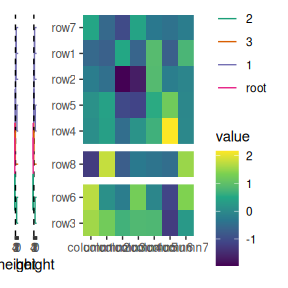

```r
ggheatmap(small_mat) +
    scale_fill_viridis_c() +
    anno_left(size = 0.2) +
    align_dendro(aes(color = branch), k = 3L) +
    align_dendro(aes(color = branch), k = 3L) -
    # Modify the the color scales of all plots in the left annotation
    scale_color_brewer(palette = "Dark2")
```

### stack_layout()

If the active layout is the `ggstack()`/`stack_layout()` itself, `-` applies the elements to all plots in the layout except the nested `ggheatmap()`/`quad_layout()`.

```
#> → heatmap built with `geom_tile()`
```

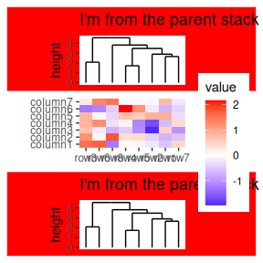

```r
stack_alignv(small_mat) +
    align_dendro() +
    ggtitle("I'm from the parent stack") +
    ggheatmap() +
    # remove any active context
    stack_active() +
    align_dendro() +
    ggtitle("I'm from the parent stack") -
    # Modify the the color scales of all plots in the stack layout except the heatmap layout
    scale_color_brewer(palette = "Dark2") -
    # set the background of all plots in the stack layout except the heatmap layout
    theme(plot.background = element_rect(fill = "red"))
```

When the active layout is the nested `ggheatmap()`/`quad_layout()`, the `-` operator applies the elements to this nested layout, following the same principles as in the `ggheatmap()`/`quad_layout()`.

Want apply elements for plots in both `stack_layout()` and the nested `ggheatmap()`/`quad_layout()` at the same time? refer to the following section.